# Set_11

Alexander Williams

2024-10-16

# Regression with a Single Predictor

Consider the case where the data has a continuous response $Y$, and a continuous variable $X$. We want to examine the relationship between $X$ and $Y$, or determine if there is one.

the data is in the form $(y_1,x_1),...,(y_n,x_n)$. X and Y might both be observed, or we might observe Y with chosen values X

we will examine data of the form:
$$y_i=f(x_i)+\epsilon_i,
\epsilon_i\sin{}N(0,1)$$
$f(x)$ is the relationship between X and Y, that we want to find out.

What assumptions are we making? we’re assuming the error for each point $\epsilon_i$ is normally distributed, always with the same variance.

we can fit a model to get the observed value $\hat{f}(x)$

there’s a number of forms that $f(x)$ might take 1. $f(x)=ax+b$ linear regression 2. $f(x)=ax^2+bx+c$ quadratic regression, or polynomial regression 3. $f(x)=a-be^{-cx}$ non-linear 4. no assumptions on $f(x)$, only that it’s smooth

lets start with linear regression

## Example: Growth and Tannin

X is measure of tannin, Y is measure of growth

```r
reg.data <- read.table(file='~/Documents/uni/STAT359/data/tannin.txt'
                       ,header=TRUE,sep="")
attach(reg.data)
names(reg.data)
```

```
## [1] "growth" "tannin"
```

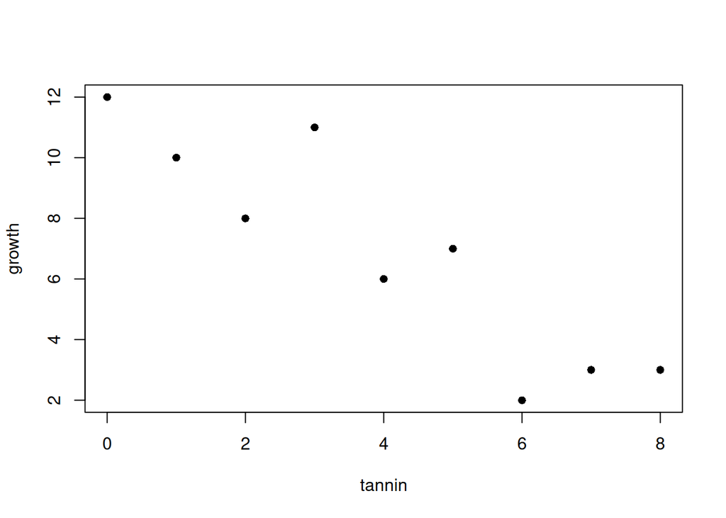

```r
plot(tannin,growth,pch=16)
```

Looks like there’s a negative correlation between growth and tannin.

How do we estimate our parameters a and b? Lets start with a rough guess

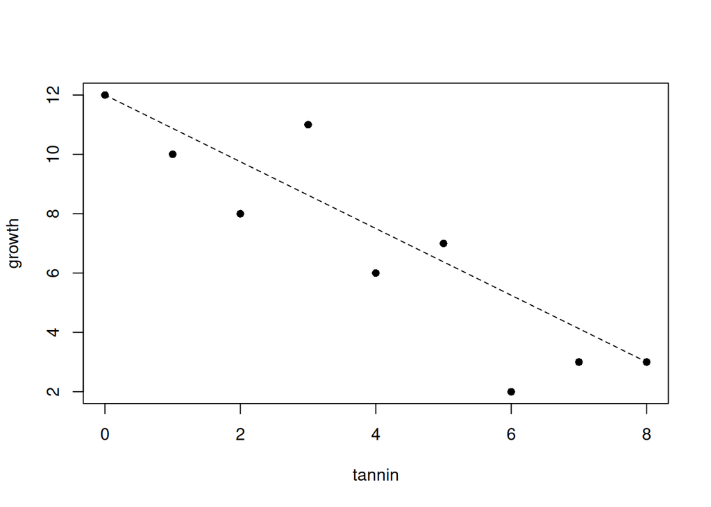

```r
plot(tannin,growth,pch=16)
## rough guess at parameter values
## intercept
a<-12
## slope
b<-(growth[9]-growth[1])/(tannin[9]-tannin[1])
## plot the guessed linear relationship
lines(tannin,a+b*tannin,lty=2)
```

This was just a guess, how can we do this to get an optimal set of parameters?

First, let’s try the least squares (LS) method

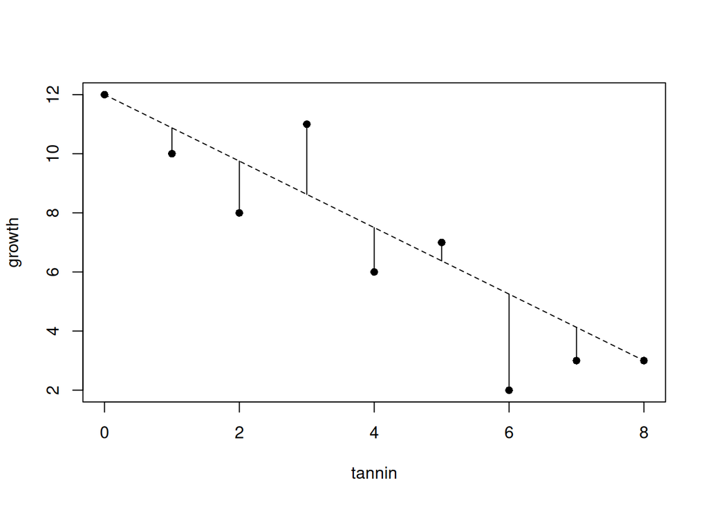

```r
plot(tannin,growth,pch=16)
## rough guess at parameter values
## intercept
a<-12
## slope
b<-(growth[9]-growth[1])/(tannin[9]-tannin[1])

## plot the guessed linear relationship
lines(tannin,a+b*tannin,lty=2)
## plot the errors
simple.fit<-a+b*tannin
for (i in 1:length(growth))
    {
    lines(c(tannin[i],tannin[i]),c(simple.fit[i],growth[i]))
    }
```

Those vertical lines are the distances from the estimate, they’re the error in this model. You square and sum them together
$$SSE=\sum_{i=1}^n(y_i-\hat{f}(x))^2$$
We want to pick $\hat{a},\hat{b}$ to minimize this value. We take the derivative of the equation, set that equal to zero, and search for the minimum. Calculus 3 math

we eventually get the following equations:
$$\hat{b}=\frac{\sum{}x_iy_i-\frac{1}{n}(\sum{}y_i)(\sum{}x_i)}{\sum{}x_i^2-\frac{(\sum{}x_i)^2}{n}}$$
$$\hat{a}=\bar{y}-\hat{b}\bar{x}$$

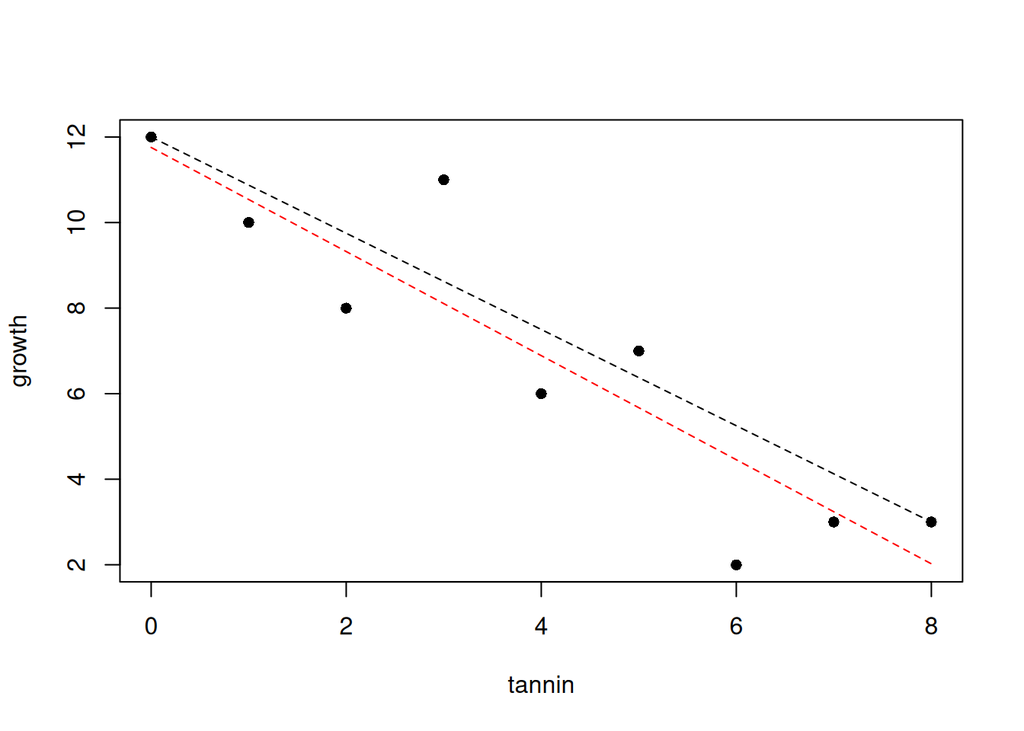

```r
## compute least squares estimators
## change notation to match the notes
y<-growth
x<-tannin

b.ls<-(sum(x*y) - sum(y)*sum(x)/length(y))/(sum(x^2) - sum(x)*sum(x)/length(x))
a.ls<-mean(y) - b.ls*mean(x)

## plot the least squares line
plot(tannin,growth,pch=16)
## plot the guessed linear relationship
lines(tannin,a+b*tannin,lty=2)
## plot the LS line
lines(tannin,a.ls+b.ls*tannin,lty=2,col="red")
```

```r
lm(growth~tannin)
```

```
##
## Call:
## lm(formula = growth ~ tannin)
##
## Coefficients:
## (Intercept)       tannin
##      11.756       -1.217
```

we also want a confidence interval for hypothesis testing, we’ll need some more values $SSX, SSY, SSXY$$ just like with ANOVA testing

$$SSY=\sum{}y_i^2-\frac{(\sum{}y_i)^2}{n}$$
$$SSX=\sum{}x_i^2-\frac{(\sum{}x_i)^2}{n}$$
Recall SSE from ANOVA, how it was used to derive a,b, we can use that again to get SSR
$$SSR=SSY-SSE$$

we use these measures of variation for hypothesis testing

```r
anova(lm(growth~tannin))
```

```
## Analysis of Variance Table
##
## Response: growth
##           Df Sum Sq Mean Sq F value    Pr(>F)
## tannin     1 88.817  88.817  30.974 0.0008461 ***
## Residuals  7 20.072   2.867
## ---
## Signif. codes:  0 '***' 0.001 '**' 0.01 '*' 0.05 '.' 0.1 ' ' 1
```

The p-value is very strong, so we have evidence against the null hypothesis that growth and tannin are unrelated.

We can also compute the p-value manually

```r
## error sum of squares
SSE<-sum((y-a.ls-b.ls*x)^2)
## total sum of squares
SSY<-sum(y^2) - (sum(y)^2)/length(y)
## regression SS
SSR<-SSY-SSE

##########################################3
## compute the p-value for F-test
F.ratio<-(SSR/1)/(SSE/7)
1-pf(F.ratio,1,7)
```

```
## [1] 0.0008460738
```

Here’s how we can easily plot the line of best fit

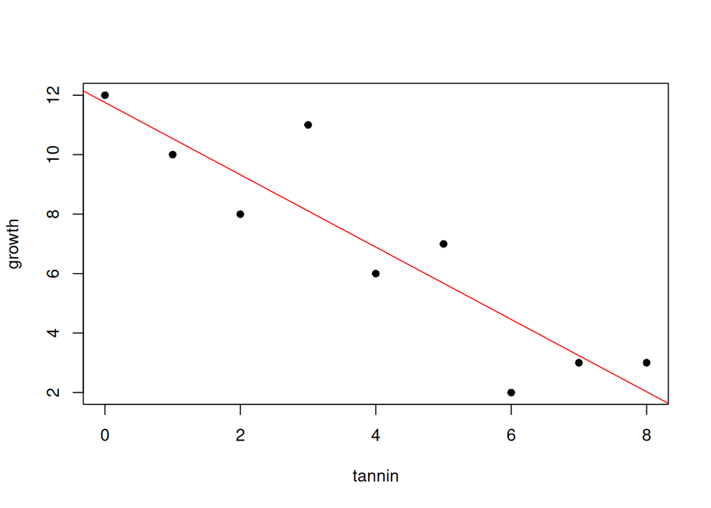

```r
## plot the least squares line
plot(tannin,growth,pch=16)
## plot the LS line
abline(lm(growth~tannin),col='red')
```

```r
lm(growth~tannin)
```

```
##
## Call:
## lm(formula = growth ~ tannin)
##
## Coefficients:
## (Intercept)       tannin
##      11.756       -1.217
```

Now, we want to get a confidence interval for the slope b

first, we get the standard error of $\hat{b}$

```r
summary(lm(growth~tannin))
```

```
##
## Call:
## lm(formula = growth ~ tannin)
##
## Residuals:
##     Min      1Q  Median      3Q     Max
## -2.4556 -0.8889 -0.2389  0.9778  2.8944
##
## Coefficients:
##             Estimate Std. Error t value Pr(>|t|)
## (Intercept)  11.7556     1.0408  11.295 9.54e-06 ***
## tannin       -1.2167     0.2186  -5.565 0.000846 ***
## ---
## Signif. codes:  0 '***' 0.001 '**' 0.01 '*' 0.05 '.' 0.1 ' ' 1
##
## Residual standard error: 1.693 on 7 degrees of freedom
## Multiple R-squared:  0.8157, Adjusted R-squared:  0.7893
## F-statistic: 30.97 on 1 and 7 DF,  p-value: 0.0008461
```

our standard error of $\hat{b}$ is 0.2186, we can use the equation:
$$\hat{b}\pm{}t_{n-2,0.025}\times{}SE(\hat{b})$$

```r
## confidence intervals
y<-growth
x<-tannin
b.ls<-(sum(x*y) - sum(y)*sum(x)/length(y))/(sum(x^2) - sum(x)*sum(x)/length(x))
a.ls<-mean(y) - b.ls*mean(x)
## want a 95% confidence interval for b
lower.b<-b.ls-0.2186*qt(p=0.975,df=length(y)-2)
upper.b<-b.ls+0.2186*qt(p=0.975,df=length(y)-2)
CI.b<-c(lower.b,upper.b)
CI.b
```

```
## [1] -1.7335735 -0.6997598
```

We can do it all at once with the confint function

```r
confint(lm(growth~tannin))
```

```
##                 2.5 %     97.5 %
## (Intercept)  9.294457 14.2166544
## tannin      -1.733601 -0.6997325
```